# Business Statistics Assessment IB94X0 2020-2021 #1

2083046

```r
library(knitr)
library(tidyverse)
library(gridExtra)
library(grid)
library(ggplot2)
library(emmeans)
library(Hmisc)
install.packages("ggcorrplot", repos = "https://cran.rstudio.com")  #for plotting correlation matrix
install.packages("sjPlot", repos = "https://cran.rstudio.com")
install.packages("sjmisc", repos = "https://cran.rstudio.com")
install.packages("sjlabelled", repos = "https://cran.rstudio.com")
library(sjPlot)
library(sjmisc)
library(sjlabelled)

options(width=100)
```

# Question 1 Section 1

Data Dictionary

| Variable | Description |
| --- | --- |
| `Outlet_ID` | Outlet ID |
| `outlettype` | Store types: community, city centre, and superstore |
| `sales_1` | Sales prior to trial |
| `sales_2` | Sales after trial |
| `staff_turnover` | Proportion of staff left the outlet during the period the data covers. |
| `sales_gain_count` | Change in actual sales (GBP): sales_2 - sales_1 |
| `sales_gain_perc` | Sales growth rate (%): (sales_2 - sales_1)/sales_1 |
| `trial` | Trial status: Trial (selected store with layout change), Non Trial (not selected store) |

Change in layout and signage positively affects sales gain i.e. sales improvement, both in terms of actual numbers and growth rate (%).

For actual numbers, stores with layout change are predicted to gain higher sales than those without the change by 439,508 GBP in average with 95% CI [293,926 - 585,090], t(494) = 5.93, p < 0.0001, which is demonstrated in figure 1.

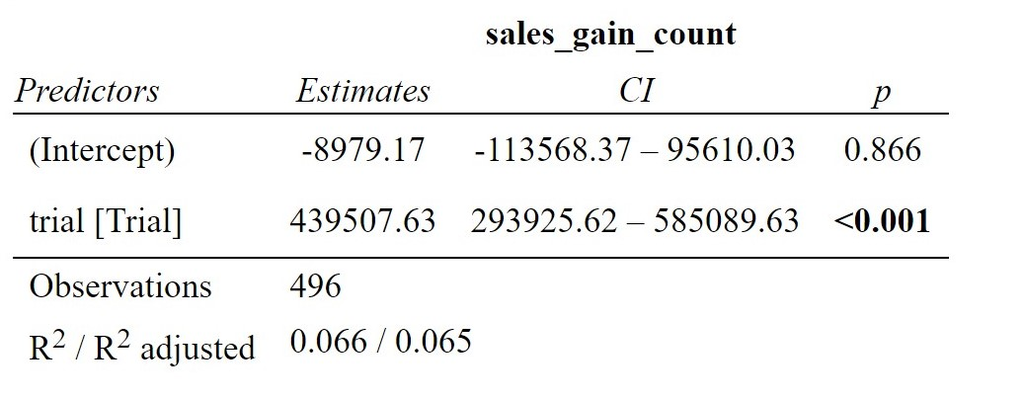

Figure 1: Actual Sales Gain Prediction from Regression

This is because the average of sales improvement for the stores with the change (trial) is 430,529 GBP, 95% CI [329,260 - 531,797] while the average of sales gain for those without the change (non-trial) is -8,979 GBP, 95% CI [-113,568 - 95,610]. The summary of estimated actual sales is depicted in figure 2.

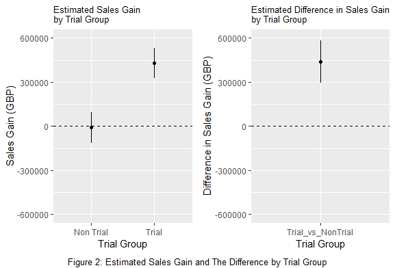

Moreover, figure 3 shows that average sales growth rate of stores as trial group is estimated to be higher than the outlets without the change (non-trial group) by 1.42% with 95% CI[0.60 - 2.25], t(494) = 3.39, p < 0.001. The estimated mean of the growth rate of trial group is 1.43%, 95% CI [0.86, 2.00] whereas for the non-trial group, the predicted mean of the growth rate is 0.005%, 95% CI [-0.59 - 0.60].

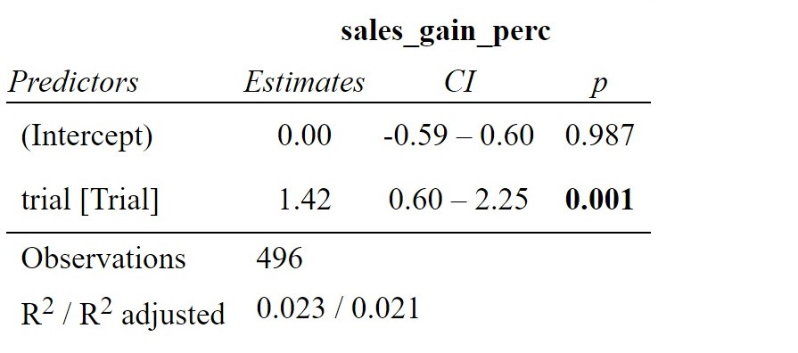

Figure 3: Sales Growth Rate Prediction from Regression

Nevertheless, actual sales prediction is relatively preferred more than sales growth rate since the R-squared is higher, 0.07 vs. 0.02 respectively. This indicates that trial status is able to explain more on the prediction compared with sales growth rate estimation. Note that the R-squared values from both predictions are low signifying that there should be more predictors to help describe the sales.

# Question 2 Section 1

Adding staff turnover is not useful for sales gain prediction, where F(1,489) = 1.25, p = 0.26 from variance analysis. Besides, the correlation between staff turnover and actual sales gain is completely low, at -0.09 as illustrated in figure 4, signifying that there is no relationship between staff turnover proportion and sales gain.

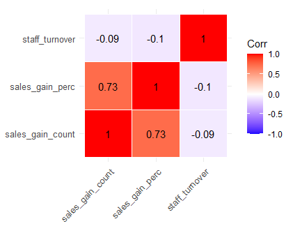

Figure 4: Correlation

As a result, using trial and outlet types as predictors is more appropriate. From figure 5, the effect of trial status significantly varies across outlet types, F(2, 490) = 34.62, p < 0.0001. This is applicable only for superstore and community store types. For example, the average sales gain for trial group is the highest at 1,355,741 GBP in superstores with 95% CI [1,158,831 - 1,552,651] while there is no effect of trial on city centre stores.

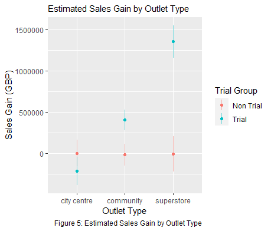

# Question 1 Section 2

```r
# Loading data
data = readr::read_csv("sales_data.csv")
View(data)
summary(data)
```

```
##   Outlet_ID          outlettype           sales_1            sales_2          intrial
##  Length:540         Length:540         Min.   :  344384   Min.   :  354421   Mode :logical
##  Class :character   Class :character   1st Qu.: 6306210   1st Qu.: 6304418   FALSE:277
##  Mode  :character   Mode  :character   Median :10550795   Median :10734004   TRUE :263
##                                        Mean   :14144900   Mean   :14362091
##                                        3rd Qu.:16183690   3rd Qu.:16207557
##                                        Max.   :65959576   Max.   :67704964
##  staff_turnover
##  Min.   :0.000000
##  1st Qu.:0.000000
##  Median :0.001232
##  Mean   :0.001993
##  3rd Qu.:0.002508
##  Max.   :0.039476
```

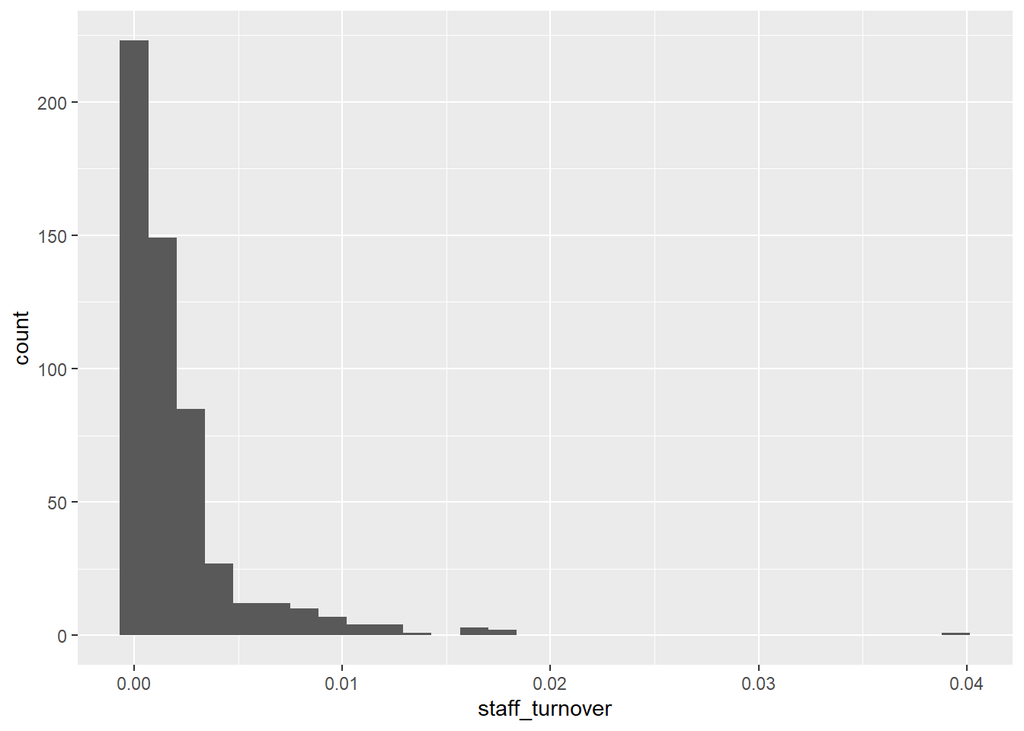

```r
# Identifying outliers using IQR
ggplot(data, aes(x=staff_turnover)) + geom_histogram()
```

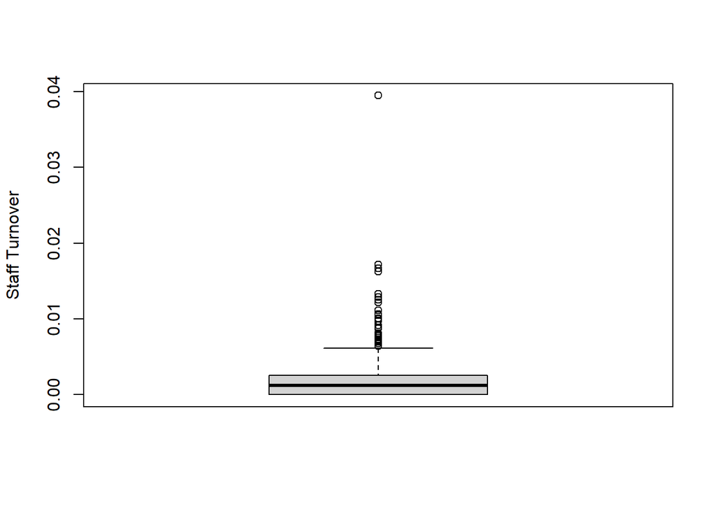

```r
outliers1 <- boxplot(data$staff_turnover, ylab = "Staff Turnover")$out
```

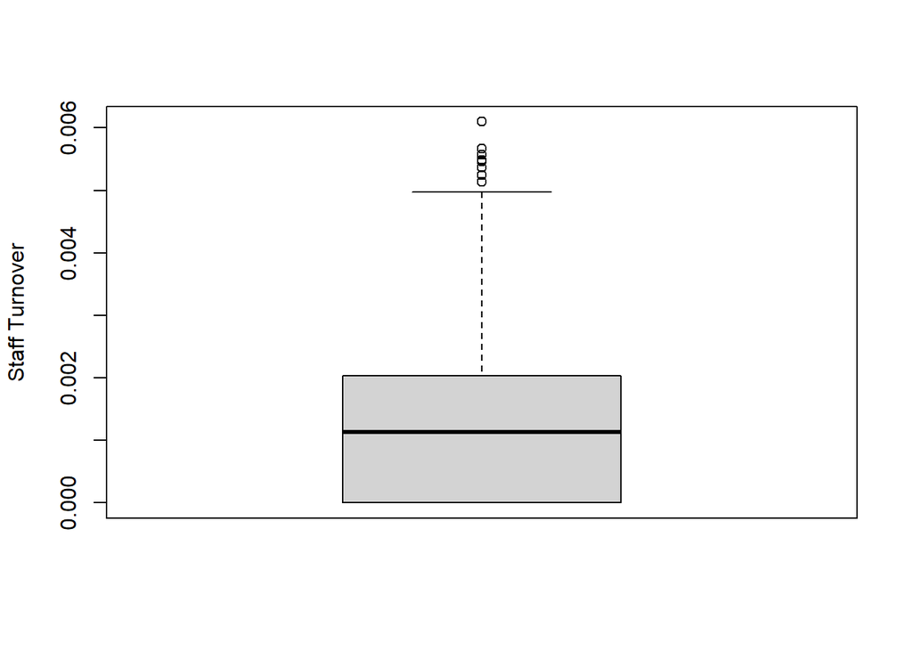

```r
# Drop the rows containing outliers
data <- data[-c(which(data$staff_turnover %in% outliers1)),]

# Boxplot without outliers
boxplot(data$staff_turnover, ylab = "Staff Turnover")
```

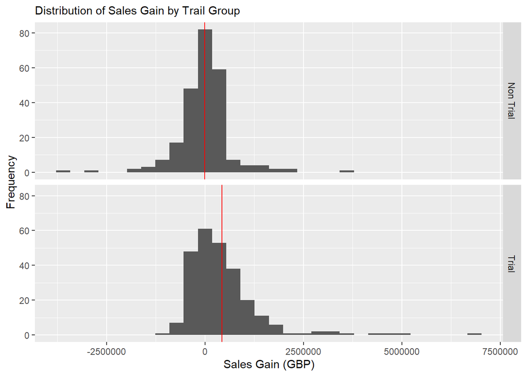

```r
# Data manipulation
data$outlettype = as.factor(data$outlettype)
data = data %>% mutate(sales_gain_count = sales_2 - sales_1, sales_gain_perc = (100 * (sales_2 - sales_1)) / sales_1, trial = ifelse(data$intrial == 'TRUE', 1, 0))
data$trial = factor(data$trial, labels = c("Non Trial", "Trial"))
data$outlettype = recode(data$outlettype, community_convenience = "community", city_centre_convenience = "city centre")

# Explore data by plotting
data.by.sector <- data %>% group_by(trial) %>% summarise(mean=mean(sales_gain_count), n=n())
ggplot(data) + geom_histogram(aes(x=sales_gain_count)) + facet_grid(trial~.) + labs(x="Sales Gain (GBP)", y="Frequency", subtitle="Distribution of Sales Gain by Trail Group") + geom_vline(data=data.by.sector, mapping=aes(xintercept=mean), col="red")
```

```r
# Modelling
set.seed(2)
m.sales_diff1 = lm(sales_gain_count ~ trial, data = data)
m.sales_diff2 = lm(sales_gain_perc ~ trial, data = data)

# Result
summary(m.sales_diff1)
```

```
##
## Call:
## lm(formula = sales_gain_count ~ trial, data = data)
##
## Residuals:
##      Min       1Q   Median       3Q      Max
## -3670595  -474636   -50682   264548  6337378
##
## Coefficients:
##             Estimate Std. Error t value Pr(>|t|)
## (Intercept)    -8979      53232  -0.169    0.866
## trialTrial    439508      74096   5.932 5.65e-09 ***
## ---
## Signif. codes:  0 '***' 0.001 '**' 0.01 '*' 0.05 '.' 0.1 ' ' 1
##
## Residual standard error: 824700 on 494 degrees of freedom
## Multiple R-squared:  0.06649,    Adjusted R-squared:  0.0646
## F-statistic: 35.18 on 1 and 494 DF,  p-value: 5.645e-09
```

```r
summary(m.sales_diff2)
```

```
##
## Call:
## lm(formula = sales_gain_perc ~ trial, data = data)
##
## Residuals:
##      Min       1Q   Median       3Q      Max
## -13.7629  -2.9852   0.3034   3.2164  12.1438
##
## Coefficients:
##             Estimate Std. Error t value Pr(>|t|)
## (Intercept) 0.004859   0.301896   0.016 0.987164
## trialTrial  1.423244   0.420221   3.387 0.000763 ***
## ---
## Signif. codes:  0 '***' 0.001 '**' 0.01 '*' 0.05 '.' 0.1 ' ' 1
##
## Residual standard error: 4.677 on 494 degrees of freedom
## Multiple R-squared:  0.02269,    Adjusted R-squared:  0.02072
## F-statistic: 11.47 on 1 and 494 DF,  p-value: 0.0007633
```

```r
tab_model(m.sales_diff1)
```

|  | sales_gain_count |  |  |
| --- | --- | --- | --- |
| Predictors | Estimates | CI | p |
| (Intercept) | -8979.17 | -113568.37 – 95610.03 | 0.866 |
| trial [Trial] | 439507.63 | 293925.62 – 585089.63 | **<0.001** |
| Observations | 496 |  |  |
| R<sup>2</sup> / R<sup>2</sup> adjusted | 0.066 / 0.065 |  |  |

```r
tab_model(m.sales_diff2)
```

|  | sales_gain_perc |  |  |
| --- | --- | --- | --- |
| Predictors | Estimates | CI | p |
| (Intercept) | 0.00 | -0.59 – 0.60 | 0.987 |
| trial [Trial] | 1.42 | 0.60 – 2.25 | **0.001** |
| Observations | 496 |  |  |
| R<sup>2</sup> / R<sup>2</sup> adjusted | 0.023 / 0.021 |  |  |

```r
# To test if trial affects sales gain
anova(m.sales_diff1)
```

```
## Analysis of Variance Table
##
## Response: sales_gain_count
##            Df     Sum Sq    Mean Sq F value    Pr(>F)
## trial       1 2.3928e+13 2.3928e+13  35.184 5.645e-09 ***
## Residuals 494 3.3596e+14 6.8008e+11
## ---
## Signif. codes:  0 '***' 0.001 '**' 0.01 '*' 0.05 '.' 0.1 ' ' 1
```

```r
anova(m.sales_diff2)
```

```
## Analysis of Variance Table
##
## Response: sales_gain_perc
##            Df  Sum Sq Mean Sq F value    Pr(>F)
## trial       1   250.9 250.916  11.471 0.0007633 ***
## Residuals 494 10805.7  21.874
## ---
## Signif. codes:  0 '***' 0.001 '**' 0.01 '*' 0.05 '.' 0.1 ' ' 1
```

```r
# Predicted means with estimation approach
cbind(coefficient=coef(m.sales_diff1), confint(m.sales_diff1))
```

```
##             coefficient     2.5 %    97.5 %
## (Intercept)    -8979.17 -113568.4  95610.03
## trialTrial    439507.63  293925.6 585089.63
```

```r
cbind(coefficient=coef(m.sales_diff2), confint(m.sales_diff2))
```

```
##             coefficient      2.5 %    97.5 %
## (Intercept) 0.004859468 -0.5882984 0.5980174
## trialTrial  1.423244353  0.5976035 2.2488852
```

```r
# Predicted means with estimation approach - alternative way
(  m.sales_diff1_means <- emmeans(m.sales_diff1, ~trial)  )
```

```
##  trial     emmean    SE  df lower.CL upper.CL
##  Non Trial  -8979 53232 494  -113568    95610
##  Trial     430529 51542 494   329260   531797
##
## Confidence level used: 0.95
```

```r
(  m.sales_diff2_means <- emmeans(m.sales_diff2, ~trial)  )
```

```
##  trial      emmean    SE  df lower.CL upper.CL
##  Non Trial 0.00486 0.302 494   -0.588    0.598
##  Trial     1.42810 0.292 494    0.854    2.002
##
## Confidence level used: 0.95
```

```r
# Contrast to see mean difference
contrast.trial <- data.frame(Trial_vs_NonTrial = c(-1,1))
contrast(m.sales_diff1_means, contrast.trial)
```

```
##  contrast          estimate    SE  df t.ratio p.value
##  Trial_vs_NonTrial   439508 74096 494 5.932   <.0001
```

```r
( contrast.CI = confint(contrast(m.sales_diff1_means, contrast.trial)) )
```

```
##  contrast          estimate    SE  df lower.CL upper.CL
##  Trial_vs_NonTrial   439508 74096 494   293926   585090
##
## Confidence level used: 0.95
```

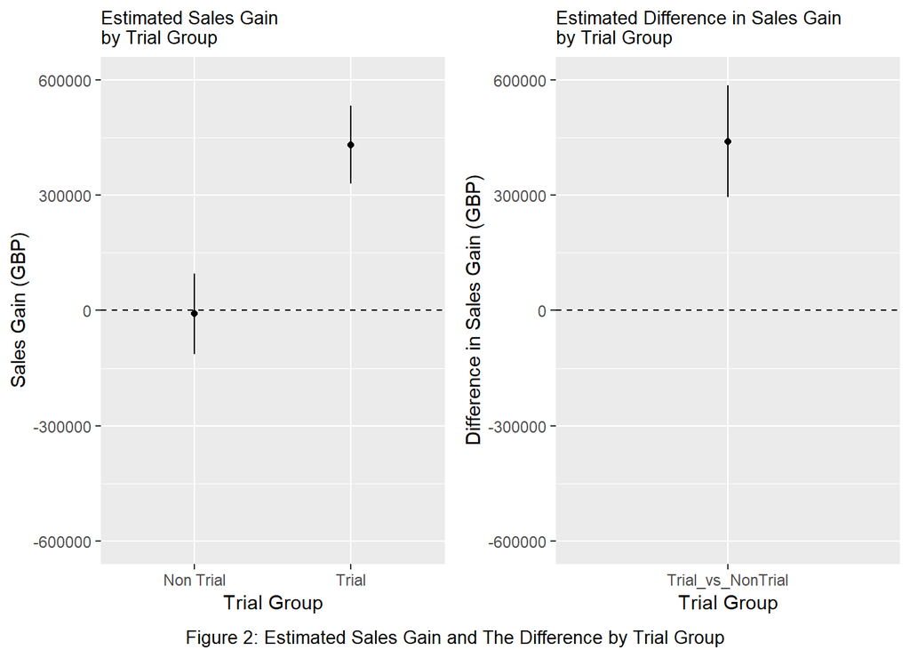

```r
# Plot the result
options(scipen=10000)

p.gain <- ggplot(summary(m.sales_diff1_means), aes(x=trial, y=emmean, ymin=lower.CL, ymax=upper.CL)) + geom_point() + geom_linerange() + geom_hline(yintercept=0, lty=2) + labs(x="Trial Group", y="Sales Gain (GBP)", subtitle="Estimated Sales Gain \nby Trial Group") + ylim(-600000,600000) + theme(plot.subtitle=element_text(size=10))

p.contrasts <- ggplot(contrast.CI, aes(x=contrast, y=estimate, ymin=lower.CL, ymax=upper.CL)) + geom_point() + geom_linerange() + geom_hline(yintercept=0, lty=2) + labs(x="Trial Group", y="Difference in Sales Gain (GBP)", subtitle="Estimated Difference in Sales Gain \nby Trial Group") + ylim(-600000,600000) + theme(plot.subtitle=element_text(size=10))

grid.arrange(p.gain, p.contrasts, ncol=2, bottom = textGrob("Figure 2: Estimated Sales Gain and The Difference by Trial Group", gp=gpar(fontsize=10, font=1)))
```

# Question 2 Section 2

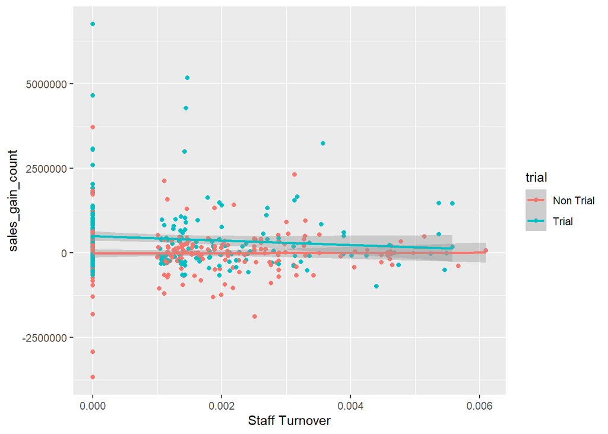

```r
# Explore the relationship between staff turnover and sales gain
data %>% ggplot(aes(x=staff_turnover, y=sales_gain_count, color = trial)) + geom_jitter() + geom_smooth(method = "lm") + xlab("Staff Turnover")
```

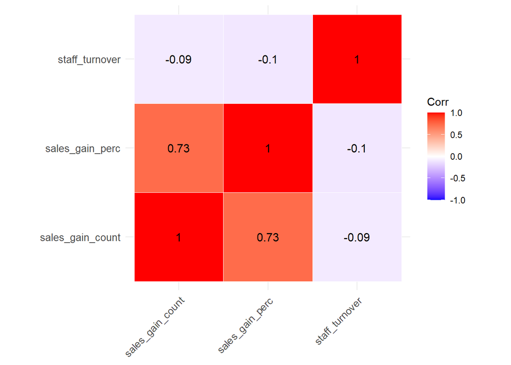

```r
# Correlation
corr = rcorr(as.matrix(select(data, sales_gain_count, sales_gain_perc, staff_turnover)))
ggcorrplot::ggcorrplot(corr$r, outline.col = "white", lab = T, tl.cex = 10)
```

```r
# Validate if "staff_turnover" affects sales gain
m.sales_diff3 = lm(sales_gain_count ~ outlettype*trial + staff_turnover, data = data)
anova(m.sales_diff3)
```

```
## Analysis of Variance Table
##
## Response: sales_gain_count
##                   Df          Sum Sq        Mean Sq F value                Pr(>F)
## outlettype         2  41094765596854 20547382798427 38.6182 0.0000000000000002679 ***
## trial              1  21100998691343 21100998691343 39.6587 0.0000000006742362652 ***
## staff_turnover     1    667502334065   667502334065  1.2546                0.2632
## outlettype:trial   2  36843110159664 18421555079832 34.6228 0.0000000000000086542 ***
## Residuals        489 260179425059051   532064263924
## ---
## Signif. codes:  0 '***' 0.001 '**' 0.01 '*' 0.05 '.' 0.1 ' ' 1
```

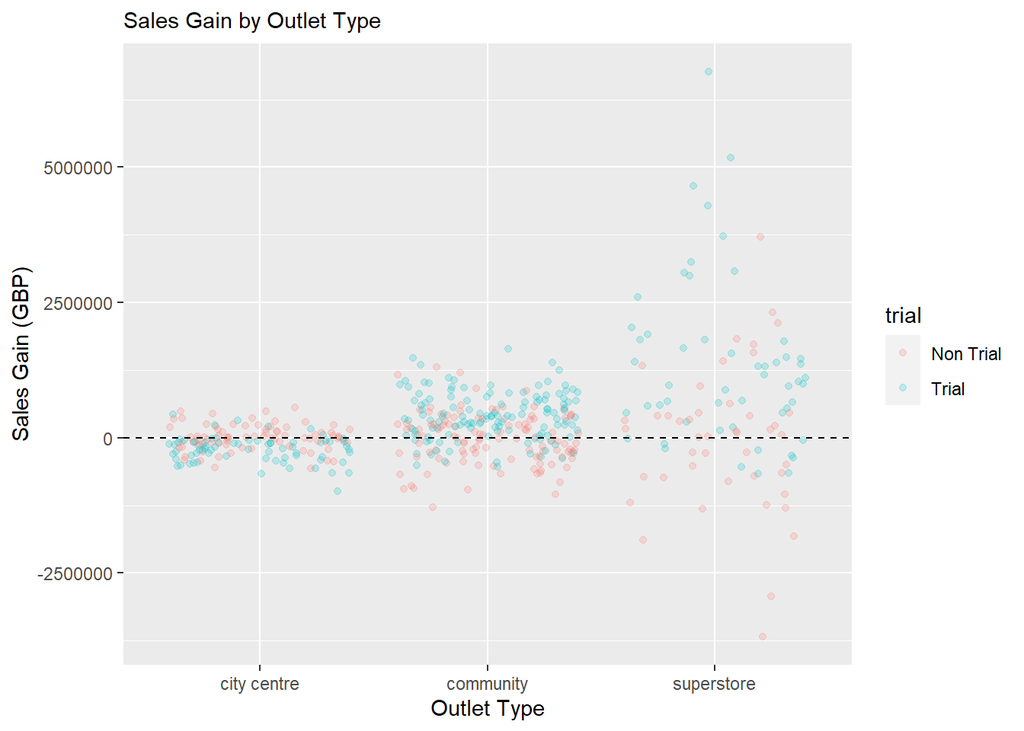

```r
# Explore sales gain by outlet type
ggplot(data, aes(x=outlettype, y=sales_gain_count, color = trial)) + geom_jitter(alpha = 0.2) + geom_hline(yintercept=0, lty=2) + labs(x = "Outlet Type", y = "Sales Gain (GBP)", subtitle = "Sales Gain by Outlet Type")
```

```r
# Generate a model to predict average sales gain
m.sales_diff4 = lm(sales_gain_count ~ outlettype*trial, data = data)
anova(m.sales_diff4)
```

```
## Analysis of Variance Table
##
## Response: sales_gain_count
##                   Df          Sum Sq        Mean Sq F value                Pr(>F)
## outlettype         2  41094765596854 20547382798427  38.600 0.0000000000000002708 ***
## trial              1  21100998691343 21100998691343  39.640 0.0000000006791364571 ***
## outlettype:trial   2  36856418037588 18428209018794  34.619 0.0000000000000086461 ***
## Residuals        490 260833619515192   532313509215
## ---
## Signif. codes:  0 '***' 0.001 '**' 0.01 '*' 0.05 '.' 0.1 ' ' 1
```

```r
# Generate the result table
tab_model(m.sales_diff4)
```

|  | sales_gain_count |  |  |
| --- | --- | --- | --- |
| Predictors | Estimates | CI | p |
| (Intercept) | 1189.08 | -159084.11 – 161462.27 | 0.988 |
| outlettype [community] | -18307.56 | -227010.84 – 190395.72 | 0.863 |
| outlettype [superstore] | -7444.70 | -274566.68 – 259677.29 | 0.956 |
| trial [Trial] | -217041.03 | -450774.12 – 16692.05 | 0.069 |
| outlettype [community] * trial [Trial] | 640875.33 | 344111.29 – 937639.37 | **<0.001** |
| outlettype [superstore] * trial [Trial] | 1579037.88 | 1206115.11 – 1951960.65 | **<0.001** |
| Observations | 496 |  |  |
| R<sup>2</sup> / R<sup>2</sup> adjusted | 0.275 / 0.268 |  |  |

```r
# Estimated sales gain and diff in sales gain
(  m.sales_diff4.emm <- emmeans(m.sales_diff4, ~trial+outlettype)  )
```

```
##  trial     outlettype   emmean     SE  df lower.CL upper.CL
##  Non Trial city centre    1189  81572 490  -159084   161462
##  Trial     city centre -215852  86587 490  -385980   -45724
##  Non Trial community    -17119  68035 490  -150796   116559
##  Trial     community    406716  63503 490   281943   531488
##  Non Trial superstore    -6256 108762 490  -219953   207442
##  Trial     superstore  1355741 100218 490  1158831  1552651
##
## Confidence level used: 0.95
```

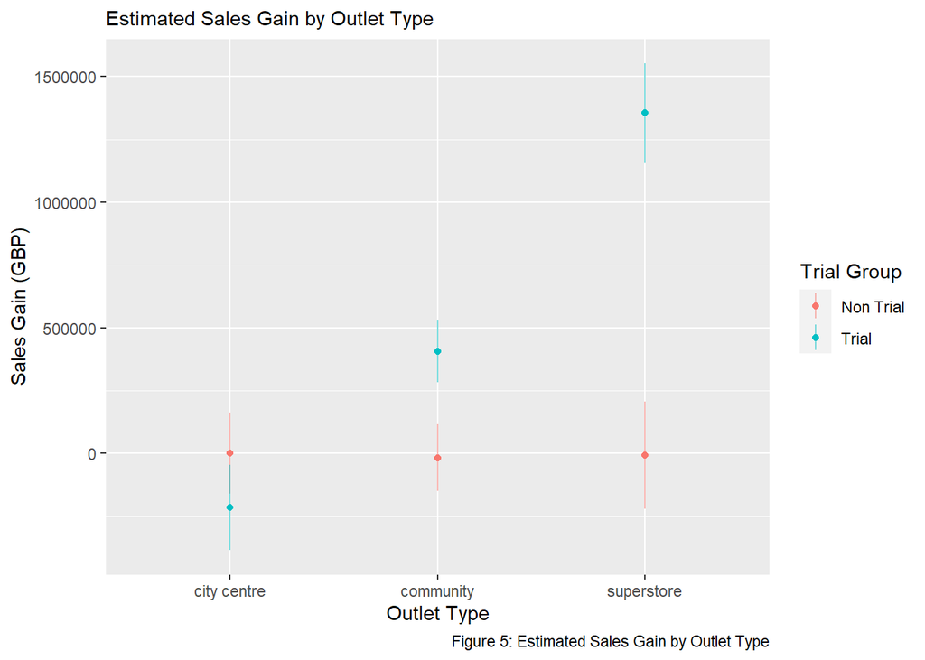

```r
# Plot estimated sales
ggplot(summary(m.sales_diff4.emm), aes(x=outlettype, y=emmean, ymin=lower.CL, ymax=upper.CL, col=trial)) + geom_point() + geom_linerange(alpha=0.5) + labs(x="Outlet Type", y="Sales Gain (GBP)", col="Trial Group", subtitle="Estimated Sales Gain by Outlet Type", caption = "Figure 5: Estimated Sales Gain by Outlet Type")
```